# Module 5

Module 5: HPC, Nextflow and Genpipes

Practical session

Author

Alie Rangel (Adapted from Rola Dali)

Published

5/1/26

[figure not shown]

[figure not shown]

## Overview

This session will introduce you to how to prepare input files to run Nextlfow and GenPipes RNAseq pipelines.

## Nextflow

Use the online [nf-core tool online](https://oldsite.nf-co.re/launch) to create a configuration file for the rnaseq pipeline version 3.26.0.

Use the following parameters:

**Click to view example output**

nf-params.json

```
{
    "input": "\/home\/User\/projects\/rrg-PIname\/User\/RNAseq_Module5\/Readset.csv",
    "outdir": "\/home\/User\/scratch\/RNAseq_Module5\/",
    "genome": "GRCh38",
    "trimmer": "fastp",
    "aligner": "bowtie2_salmon"
}
```

## Genpipes

### Preparing input files

The input files to run this pipeline are the following:

- All pipelines require 2 files:
  - Configuration “.ini” file: contains parameters used by tools in the pipeline
  - Readset file: contains details about your samples
- Optional:
  - Steps selection: defines the steps of the pipeline to be run
- A few pipelines require:
  - Design file: contains details about sample comparisons (e.g. RNA-seq, ChiP-seq, etc…)

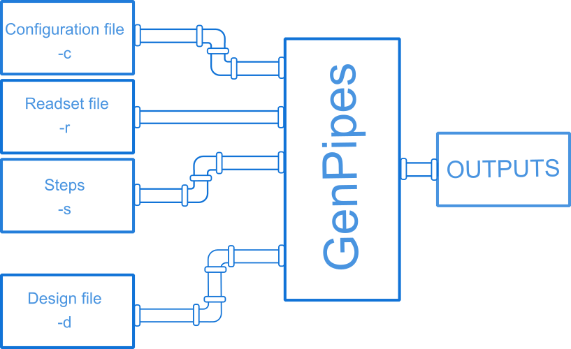

#### Creating the Readset file

The readset file is a tab separated file that describes the sequencing data and to which sample it belongs to:

- Readset used for analysis
- Samples to be merged
- Location of FASTQ/BAM input files.

Create a Readset file in Excel using the samples from the GSE311541 [GEO accession muber](https://www.ncbi.nlm.nih.gov/geo/query/acc.cgi?acc=GSE311541). These samples come from Mus musculus embryos with and without cardiomyocyte-specific Pkn2 knockout (cKO). Prepare a readset file for all samples.

Start by pasting this headers in a new Excel sheet:

```markdown
Sample  Readset Library RunType Run Lane  Adapter1  Adapter2  QualityOffset BED FASTQ1  FASTQ2
```

**Tip**

Look at what library preparation kit they used to choose the adapters. Some of the most popular used kits can be found on this [page](https://support-docs.illumina.com/SHARE/AdapterSequences/Content/AdapterSeq.htm).

Make sure to save it as a tab-separated file.

**Click to view answer**

| Sample | Readset | Library | RunType | Run | Lane | Adapter1 | Adapter2 | QualityOffset | BED | FASTQ1 | FASTQ2 |
| --- | --- | --- | --- | --- | --- | --- | --- | --- | --- | --- | --- |
| GSM9326769_ko | R1 |  | paired_end | SRR36201369 | 1 | AGATCGGAAGAGCACACGTCTGAACTCCAGTCA | AGATCGGAAGAGCGTCGTGTAGGGAAAGAGTGT |  |  | GSM9326769_R1.fastq.gz | GSM9326769_R2.fastq.gz |
| GSM9326770_ko | R1 |  | paired_end | SRR36201377 | 1 | AGATCGGAAGAGCACACGTCTGAACTCCAGTCA | AGATCGGAAGAGCGTCGTGTAGGGAAAGAGTGT |  |  | GSM9326770_R1.fastq.gz | GSM9326770_R2.fastq.gz |
| GSM9326771_ko | R1 |  | paired_end | SRR36201376 | 1 | AGATCGGAAGAGCACACGTCTGAACTCCAGTCA | AGATCGGAAGAGCGTCGTGTAGGGAAAGAGTGT |  |  | GSM9326771_R1.fastq.gz | GSM9326771_R2.fastq.gz |
| GSM9326772_ko | R1 |  | paired_end | SRR36201375 | 1 | AGATCGGAAGAGCACACGTCTGAACTCCAGTCA | AGATCGGAAGAGCGTCGTGTAGGGAAAGAGTGT |  |  | GSM9326772_R1.fastq.gz | GSM9326772_R2.fastq.gz |
| GSM9326773_ctrl | R1 |  | paired_end | SRR36201378 | 1 | AGATCGGAAGAGCACACGTCTGAACTCCAGTCA | AGATCGGAAGAGCGTCGTGTAGGGAAAGAGTGT |  |  | GSM9326773_R1.fastq.gz | GSM9326773_R2.fastq.gz |
| GSM9326774_ctrl | R1 |  | paired_end | SRR36201374 | 1 | AGATCGGAAGAGCACACGTCTGAACTCCAGTCA | AGATCGGAAGAGCGTCGTGTAGGGAAAGAGTGT |  |  | GSM9326774_R1.fastq.gz | GSM9326774_R2.fastq.gz |
| GSM9326775_ctrl | R1 |  | paired_end | SRR36201373 | 1 | AGATCGGAAGAGCACACGTCTGAACTCCAGTCA | AGATCGGAAGAGCGTCGTGTAGGGAAAGAGTGT |  |  | GSM9326775_R1.fastq.gz | GSM9326775_R2.fastq.gz |
| GSM9326776_ctrl | R1 |  | paired_end | SRR36201372 | 1 | AGATCGGAAGAGCACACGTCTGAACTCCAGTCA | AGATCGGAAGAGCGTCGTGTAGGGAAAGAGTGT |  |  | GSM9326776_R1.fastq.gz | GSM9326776_R2.fastq.gz |

#### Creating the Design file

Many pipelines need a design file to indicate the comparison to do differential expression analysis and statistical modeling.

Use Excel to create a design file that compares the two groups of sample used to build the Readset file (control vs knockout).

Start by pasting these headers in a new Excel sheet:

```markdown
Sample  Contrast1
```

**Note**

The sample names should be written exactly as in the “Sample” column of the Readset file.

Make sure to save it as a tab-separated file.

**Click to view answer**

| Sample | Contrast1 |
| --- | --- |
| GSM9326769_ko | 1 |
| GSM9326770_ko | 1 |
| GSM9326771_ko | 1 |
| GSM9326772_ko | 1 |
| GSM9326773_ctrl | 2 |
| GSM9326774_ctrl | 2 |
| GSM9326775_ctrl | 2 |
| GSM9326776_ctrl | 2 |

### Creating GenPipes command script

You are ready to run the GenPipes command to generate the pipeline script once you have all the input elements for the pipeline:

- configuration files are identified
- select alla steps in the rnaseq_light pipeline
- readset and design files are ready

The GenPipes command will look like this:

```bash
genpipes rnaseq_light
    -c $GENPIPES_INIS/rnaseq_light/rnaseq_light.base.ini \
    $GENPIPES_INIS/common_ini/narval.ini \
    $MUGQIC_INSTALL_HOME/genomes/species/Mus_musculus.GRCm38/Mus_musculus.GRCm38.ini \
    -r readset.txt \
    -s 1-8 \
    -d design.txt \
    -g rnaseq_light_genpipes.sh\
    -o /homo/USER/scratch/c3g-workshop-M3/Genpipes_output \
```

You will get the GenPipes script with all the nessesary information and dependence structure to run the pipeline, under the name of `rnaseq_light_genpipes.sh`.

**Caution**

The Genpipes command does not run the pipeline. You still need to execute the script that was created.

```bash
bash rnaseq_light_genpipes.sh
```

### Outputs

As jobs finish, log files will be created in the “job_output” folder.

Additionally, for every analysis step, a folder will be created with the appropriate output files.

Look at the files in the following link to get familiar to [GenPipes rnaseq pipeline output](https://drive.google.com/drive/folders/10VYIhmSlIqk_Pemm5Em_148axZx4Tmt0?usp=sharing). It is a good time to ask questions about the files.